# Exploratory Analyses

5/28/2021

I collected data on a number of categorical variables not directly connected to my hypotheses. Using those variables, there are a few types of exploratory analyses I’d like to undertake here.

First, I want to collect some basic descriptive statistics on the additional variables to cite in the participants’ section of the thesis.

The extra variables I have are:

- `gender`: male or female
- `ethnic`: standard racial categories used in the United States
- `age` (self-explanatory)
- `employ`: standard economic measure of employment status
- `educat`: the highest degree earned
- `party`: political stance on left-right spectrum
- `adhd`: who the participant knows with ADHD
- `work`: work history with white-, blue-, and pink-collar occupations

For all of the above, participants could click ‘Other’ and write in whatever they chose. A small, but significant, number of participants chose to do so.

As usual, I will load my packages and import the data.

```r
library(corrr)
library(tidyverse)

library(flextable)

adhd.data <- readRDS(file.path("..", "data", "hq-data.rds"))
formatAsTable <- readRDS("format.rds")
```

## Descriptive Statistics

```r
extra <- c("gender", "ethnic", "age", "employ",
           "educat", "party", "adhd", "work")

adhd.data %>%
  select(extra) %>%
  head %>%
  formatAsTable
```

| gender | ethnic | age | employ | educat | party | adhd | work |
| --- | --- | --- | --- | --- | --- | --- | --- |
| Male | White or Caucasian | 27 | Full-time | Bachelor's degree | Moderate | Family member,Acquaintance | service |
| Male | White or Caucasian | 30 | Full-time | Bachelor's degree | Conservative | I do not know anyone with ADHD | professional |
| Male | White or Caucasian | 33 | Full-time | Bachelor's degree | Conservative | Prefer not to answer | professional |
| Female | White or Caucasian | 54 | Full-time | High school diploma | Liberal | Friend | service |
| Male | Hispanic or Latino | 40 | Full-time | Other | Liberal | Myself,Friend | Prefer not to answer |
| Male | Other | 34 | Full-time | Bachelor's degree | Moderate | Family member,Friend,Acquaintance | service |

### Gender

```r
adhd.data %>%
  count(gender) %>%
  formatAsTable
```

| gender | n |
| --- | --- |
| Female | 205 |
| Male | 195 |
| Other | 1 |
| Prefer not to answer | 2 |

### Race

```r
adhd.data %>%
  select(contains("ethnic_") & !ethnic_5_text) %>%
  map_int(sum) %>%
  enframe("var", "count") %>%
  arrange(desc(count)) %>%
  formatAsTable
```

| var | count |
| --- | --- |
| ethnic_white | 312 |
| ethnic_asian | 48 |
| ethnic_black | 31 |
| ethnic_hispanic | 22 |
| ethnic_other | 4 |
| ethnic_prefer | 2 |

### Age

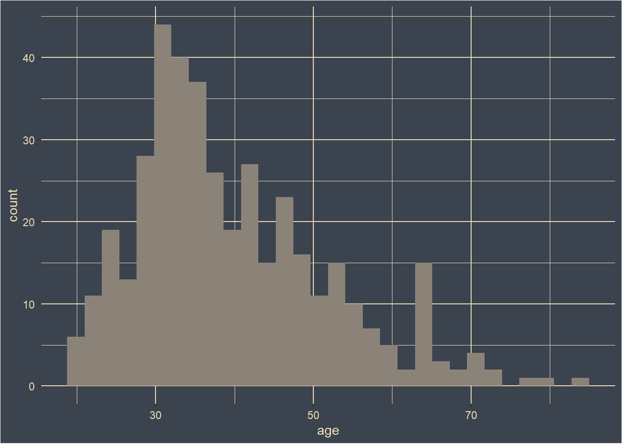

```r
plotTheme <- function() {
  theme(plot.background = element_rect(fill = '#3b434f'),
        panel.background = element_rect(fill = '#3b434f'),
        text = element_text(color = "wheat"),
        panel.grid = element_line(color = "wheat"),
        axis.text = element_text(color = "wheat"))
}

adhd.data %>%
  ggplot(aes(age)) +
  geom_histogram(fill = "antiquewhite4") +
  plotTheme()
```

### Employment Status

```r
adhd.data %>%
  count(employ) %>%
  arrange(desc(n)) %>%
  formatAsTable
```

| employ | n |
| --- | --- |
| Full-time | 263 |
| Part-time | 56 |
| Not currently working or looking for work | 24 |
| Unemployed | 23 |
| Other | 15 |
| Student | 11 |
| Prefer not to answer | 10 |
| Temporary | 1 |

### Political Ideology

```r
adhd.data %>%
  count(party) %>%
  arrange(desc(n)) %>%
  formatAsTable
```

| party | n |
| --- | --- |
| Liberal | 190 |
| Conservative | 103 |
| Moderate | 100 |
| Other | 6 |
| Prefer not to answer | 4 |

### ADHD Relationships

```r
adhd.data %>%
  select(contains("adhd_") & !contains("text")) %>%
  map_int(sum) %>%
  enframe("var", "count") %>%
  arrange(desc(count)) %>%
  formatAsTable
```

| var | count |
| --- | --- |
| adhd_nobody | 134 |
| adhd_friend | 134 |
| adhd_family | 124 |
| adhd_acquaintance | 85 |
| adhd_myself | 42 |
| adhd_coworker | 42 |
| adhd_classmate | 17 |
| adhd_prefer | 8 |

```r
somebody.vars <- c("friend", "family", "acquaintance",
                   "coworker", "classmate") %>%
  paste0("adhd_", .)

adhd.data <- adhd.data %>%
  rowwise() %>%
  mutate(adhd_somebody = any(unlist(across(somebody.vars))),
         adhd_simple = factor(ifelse(adhd_myself, "myself",
                                     ifelse(adhd_somebody, "somebody",
                                            "nobody"))))

adhd.data %>%
  count(adhd_simple) %>%
  arrange(desc(n)) %>%
  formatAsTable
```

| adhd_simple | n |
| --- | --- |
| somebody | 221 |
| nobody | 140 |
| myself | 42 |

### Work History

```r
adhd.data %>%
  select(contains("work_") & !contains("text")) %>%
  map_int(sum) %>%
  enframe("var", "count") %>%
  arrange(desc(count)) %>%
  formatAsTable
```

| var | count |
| --- | --- |
| work_professional | 248 |
| work_service | 179 |
| work_manual | 75 |
| work_other | 22 |
| work_prefer | 16 |

### Education

```r
adhd.data %>%
  count(educat) %>%
  arrange(desc(n)) %>%
  formatAsTable
```

| educat | n |
| --- | --- |
| Bachelor's degree | 190 |
| High school diploma | 92 |
| Master's degree | 54 |
| Associate's degree | 52 |
| Doctoral degree | 6 |
| Other | 5 |
| Prefer not to answer | 4 |

Output document:

```r
options(knitr.duplicate.label = "allow")
rmarkdown::render("exploratory.Rmd",
                  output_dir = file.path("..", "github", "thesis"))
```